# primer_selection

Hongxi

2023-11-28

# 引物设计流程

## 定义所需函数

在流程开始前定义流程所需的函数，其包括：  
1. `reverseDNA`：反向互补序列函数。输入**DNA序列**的反向DNA序列  
2. `align_all`: 序列比对函数。输入A、B两条序列，将返回A序列在B序列（以及B序列的反向互补序列）中出现的总次数。  
3. `GC_contain`: 计算GC含量的函数。返回输入序列的GC百分比含量。  
4. `get_all_primers`:批量获取引物序列。从输入的序列中获取所有在某个长度范围内的子序列（以及其所在位置）并放入一个数据框后返回。需要输入的参数有最小值（`minsize`）、最大值（`maxsize`）、DNA长度（`DNAsize`）、DNA序列（`DNAseq`）。

```r
#配置函数
##获取反向DNA序列(5'-3')
reverseDNA <- function(DNA) {
  q1 <- c("A","G","C","T")
  q2 <- c("T","C","G","A")

  names(q2)=q1

  F_seq <- DNA
  R_seq <- paste(rev(q2[unlist(strsplit(F_seq,""))]),collapse = "")

  return(R_seq)
}

##序列比对函数:返回相同序列的个数（包括反向序列上的）
align_all <- function(query,subject) {

  c_query <- reverseDNA(DNA=query)

  F_matches <- str_count(subject,query)
  R_matches <- str_count(subject,c_query)

  all_matches <- F_matches + R_matches
  return(all_matches)
}

##GC含量函数
GC_contain <- function(DNA) {
  GC <- (str_count(DNA, "G")+str_count(DNA, "C"))/nchar(DNA)*100
  GC <- round(GC,2)
  return(GC)
}

##获取字符串中特定长度的子集并标注位置
get_all_primers <- function(minsize, maxsize, DNAsize, DNAseq) {

  get_primer_positions <- function(minsize, maxsize, DNAsize) {

    primer_size_range <- minsize:maxsize

    get_position <- function(DNAsize,primer_size) {
    startpoint <- 1:(DNAsize - primer_size + 1)
    endpoint <- primer_size:DNAsize

    temdata <- data.frame(start = startpoint, end = endpoint)

    return(temdata)
    }

    position_list <- mapply(get_position,
                            DNAsize = DNAsize,
                            primer_size = primer_size_range)

    position_map <- lapply(data.frame(position_list), as.list)

    primer_all_position <- do.call(bind_rows, position_map)
    primer_all_position$accession <- 1:length(primer_all_position$start)

    return(primer_all_position)
  }

  primer_positions <- get_primer_positions(minsize = minsize,
                                           maxsize = maxsize,
                                           DNAsize = DNAsize)

  primer_positions$seq <- str_sub(DNAseq, start = primer_positions$start, end = primer_positions$end)

  return(primer_positions)
}
```

## 加载所需要的包

该流程需要使用以下常用处理字符串的包：  
1. `stringr`  
2. `dplyr`  
3. `tidyr`

运行以下代码加载包

```r
#加载包
library(stringr)
library(dplyr)
library(tidyr)
```

## 开始分析

```r
#加载数据并初步处理
setwd("C:/Users/Hongxi/Documents/R_project")
F_DNA <- paste(readLines("ACTB.fna"), collapse = "")
R_DNA <- reverseDNA(DNA = F_DNA)
```

```r
#目标序列基础分析
target_size <- nchar(F_DNA)

target_GC <- GC_contain(F_DNA)
```

## 单条引物的预筛选

根据引物大小，使用本流程预先设定的函数`get_all_primers`选出所有长度范围内的子序列以减少运算量。

```r
#输入引物大小限制

primer_size_min <- 19
primer_size_max <- 21

#获取潜在引物序列
F_primer_all <- get_all_primers(minsize = primer_size_min,
                                maxsize = primer_size_max,
                                DNAsize = target_size,
                                DNAseq = F_DNA)
R_primer_all <- get_all_primers(minsize = primer_size_min,
                                maxsize = primer_size_max,
                                DNAsize = target_size,
                                DNAseq = R_DNA)
```

## 单条引物的筛选

[figure not shown]

4. 引物自身3端配对  
5. 引物与靶标的3端配对

其中,引物自身配对的限制是为了尽量避免发卡结构和引物二聚体的产生，与靶标的3端限制是为了避免与靶标的非特异性扩增。但是这种方法无法准确排除发卡结构和引物二聚体，因此外部软件的介入可能是必要的。

调整相关参数（GC含量、Tm范围、引物自身3端配对上限（含）、引物与靶标配对上限（含））后运行以下代码，可得两个分别包含正反向可用单条引物的数据框

```r
#单引物筛选
##设定GC含量阈值
GC_min <- 50
GC_max <- 60

##计算CG含量(此处应该可以优化)
F_primer_all$GC <- unlist(lapply(as.list(F_primer_all$seq), GC_contain))
R_primer_all$GC <- unlist(lapply(as.list(R_primer_all$seq), GC_contain))

##根据GC阈值筛选
F_primer <- subset(F_primer_all, subset = GC >= GC_min & GC<=GC_max)
R_primer <- subset(R_primer_all, subset = GC >= GC_min & GC<=GC_max)


##设定Tm阈值 (后期tm阈值应与GC含量协同)
Tm_min <- 54
Tm_max <- 58

##计算Tm值：暂时使用Tm = 4(G+C)+2(A+T)计算（可优化)
F_primer$Tem <- 2*(F_primer$GC/100 + 1)*(F_primer$end - F_primer$start)

R_primer$Tem <- 2*(R_primer$GC/100 + 1)*(R_primer$end - R_primer$start)

##根据Tm值筛选

F_primer <- subset(F_primer, subset = Tem >= Tm_min & Tem <= Tm_max)
R_primer <- subset(R_primer, subset = Tem >= Tm_min & Tem <= Tm_max)


##输入引物3端配对数上限
self_match_max <- 5
##引物3端自身配对筛选
F_primer$reversed_tail <- str_sub(sapply(as.list(F_primer$seq),reverseDNA), end = self_match_max)
F_primer$self_tail_match <- str_count(F_primer$seq,F_primer$reversed_tail)


R_primer$reversed_tail <- str_sub(sapply(as.list(R_primer$seq),reverseDNA), end = self_match_max)
R_primer$self_tail_match <- str_count(R_primer$seq,R_primer$reversed_tail)

F_primer <- subset(F_primer,
                   subset = self_tail_match == 0,
                   select = c("accession","seq","start","end","GC","Tem"))
R_primer <- subset(R_primer,
                   subset = self_tail_match == 0,
                   select = c("accession","seq","start","end","GC","Tem"))


##输入引物3端与靶标配对数上限
target_match_max <-7
##引物3端与靶标筛选
F_primer$tail <- str_sub(F_primer$seq, - target_match_max)
F_primer$tail_match <- mapply(align_all, as.list(F_primer$tail), as.list(F_primer$seq))

R_primer$tail <- str_sub(R_primer$seq, - target_match_max)
R_primer$tail_match <- mapply(align_all, as.list(R_primer$tail), as.list(R_primer$seq))

F_primer <- subset(F_primer,
                   subset = tail_match == 1,
                   select = c("accession","seq","start","end","GC","Tem"))
colnames(F_primer) <- c("F_accession", "F_seq", "F_start", "F_end","F_GC","F_Tem")

R_primer <- subset(R_primer,
                   subset = tail_match == 1,
                   select = c("accession","seq","start","end","GC","Tem"))
colnames(R_primer) <- c("R_accession", "R_seq", "R_start", "R_end","R_GC","R_Tem")

#查看前20行引物所在的数据框
print(F_primer[1:20,])
```

```
## # A tibble: 20 × 6
##    F_accession F_seq               F_start F_end  F_GC F_Tem
##          <int> <chr>                 <int> <int> <dbl> <dbl>
##  1          27 AGCACAGAGCCTCGCCTTT      27    45  57.9  56.8
##  2         338 TCTTTGTCTGAGCCGGGCT     338   356  57.9  56.8
##  3         340 TTTGTCTGAGCCGGGCTCT     340   358  57.9  56.8
##  4         341 TTGTCTGAGCCGGGCTCTT     341   359  57.9  56.8
##  5         353 GGCTCTTGCCAATGGGGAT     353   371  57.9  56.8
##  6         354 GCTCTTGCCAATGGGGATC     354   372  57.9  56.8
##  7         355 CTCTTGCCAATGGGGATCG     355   373  57.9  56.8
##  8         356 TCTTGCCAATGGGGATCGC     356   374  57.9  56.8
##  9         357 CTTGCCAATGGGGATCGCA     357   375  57.9  56.8
## 10         358 TTGCCAATGGGGATCGCAG     358   376  57.9  56.8
## 11         439 CTGGTCCTTTGGGCGCTAA     439   457  57.9  56.8
## 12         440 TGGTCCTTTGGGCGCTAAC     440   458  57.9  56.8
## 13         441 GGTCCTTTGGGCGCTAACT     441   459  57.9  56.8
## 14         442 GTCCTTTGGGCGCTAACTG     442   460  57.9  56.8
## 15         443 TCCTTTGGGCGCTAACTGC     443   461  57.9  56.8
## 16         445 CTTTGGGCGCTAACTGCGT     445   463  57.9  56.8
## 17         446 TTTGGGCGCTAACTGCGTG     446   464  57.9  56.8
## 18         467 CGCTGGGAATTGGCGCTAA     467   485  57.9  56.8
## 19         468 GCTGGGAATTGGCGCTAAT     468   486  52.6  54.9
## 20         471 GGGAATTGGCGCTAATTGC     471   489  52.6  54.9
```

```r
print(R_primer[1:20,])
```

```
## # A tibble: 20 × 6
##    R_accession R_seq               R_start R_end  R_GC R_Tem
##          <int> <chr>                 <int> <int> <dbl> <dbl>
##  1          40 GTCAGTGTACAGGTAAGCC      40    58  52.6  54.9
##  2          41 TCAGTGTACAGGTAAGCCC      41    59  52.6  54.9
##  3          42 CAGTGTACAGGTAAGCCCT      42    60  52.6  54.9
##  4          43 AGTGTACAGGTAAGCCCTG      43    61  52.6  54.9
##  5          44 GTGTACAGGTAAGCCCTGG      44    62  57.9  56.8
##  6          45 TGTACAGGTAAGCCCTGGC      45    63  57.9  56.8
##  7          46 GTACAGGTAAGCCCTGGCT      46    64  57.9  56.8
##  8          47 TACAGGTAAGCCCTGGCTG      47    65  57.9  56.8
##  9          74 CACTCCCAGGGAGACCAAA      74    92  57.9  56.8
## 10          75 ACTCCCAGGGAGACCAAAA      75    93  52.6  54.9
## 11          76 CTCCCAGGGAGACCAAAAG      76    94  57.9  56.8
## 12          77 TCCCAGGGAGACCAAAAGC      77    95  57.9  56.8
## 13          79 CCAGGGAGACCAAAAGCCT      79    97  57.9  56.8
## 14          80 CAGGGAGACCAAAAGCCTT      80    98  52.6  54.9
## 15          81 AGGGAGACCAAAAGCCTTC      81    99  52.6  54.9
## 16          82 GGGAGACCAAAAGCCTTCA      82   100  52.6  54.9
## 17         102 ACATCTCAAGTTGGGGGAC     102   120  52.6  54.9
## 18         103 CATCTCAAGTTGGGGGACA     103   121  52.6  54.9
## 19         111 GTTGGGGGACAAAAAAGGG     111   129  52.6  54.9
## 20         112 TTGGGGGACAAAAAAGGGG     112   130  52.6  54.9
```

## 额外限制条件

此外，有资料表明引物3端避开密码子的第三位也能提升扩增效率。值得注意的是，也有相关论点认为过多的GC在3端聚集可能会导致非特异性扩增。后续在单个引物的筛选阶段加入该限制可能也是有必要的。

## 引物对的筛选

与单个引物筛选类似，此处使用的筛选条件有：  
1. 扩增子长度  
2. 引物对的Tm差异  
3. 引物间的3端连续配对个数  
4. 引物间任一连续碱基配对个数

在大部分资料中，限制引物间的配对主要是由认为选择的标准，如5bp或7bp。其本质在于考虑引物序列的互补链的相似性，可能后期可以将BLAST比对使用到其中，或者设计一个打分规则判断引物对的可用性。可能需要检测引物对的外部软件如IDT以获得高质量的结果。

调整扩增子长度、引物Tm差值、引物间3端配对上限（含）、引物间任意互补上限（含）后运行以下代码，符合条件的引物对（包括其序列、5-3端位置、GC含量、Tm值）将被放于数据框中并输出。

该步骤运算量较大，通常需要20s，但根据靶标序列的变大和限制条件的放松，运算时间可能会达数分钟。

```r
#引物对筛选
##输入引物对限制条件
pcr_max <- 200
pcr_min <- 100

deltar_Tm <- 2

##获取潜在引物对表,并根据限制筛选

get_all_primer_sets <- function(F_primer,R_primer,target_size,pcr_min,pcr_max,deltar_Tm,end_match, total_match){

  F_primer_list <- split(F_primer,F_primer$F_accession)

  get_primer_sets <- function(f_primer_data,r_primer_data, target_size, pcr_min, pcr_max, deltar_Tm) {

      primer_sets <- merge(f_primer_data,r_primer_data, all = T)

      primer_sets$pcr_length <- target_size-(primer_sets$R_start+primer_sets$F_start)
      primer_sets$pcr_distance <- target_size -(primer_sets$R_end + primer_sets$F_end)
      primer_sets$D_Tm <- primer_sets$R_Tem - primer_sets$F_Tem

      primer_sets <- subset(primer_sets,
                              subset = pcr_length >= pcr_min
                            & pcr_length <= pcr_max
                            & pcr_distance >= 0
                            & D_Tm <= deltar_Tm
                            & D_Tm >= -deltar_Tm,
                              select = c("R_seq", "R_start", "R_end","R_GC","R_Tem", "F_seq", "F_start", "F_end","F_GC","F_Tem","pcr_distance"))

      return(primer_sets)
  }

  primer_sets_list <-lapply(F_primer_list,get_primer_sets,
                            f_primer_data = R_primer,
                            target_size = target_size,
                            pcr_min=pcr_min,
                            pcr_max=pcr_max,
                            deltar_Tm = deltar_Tm)

  primer_sets <- do.call(rbind,primer_sets_list)

  return(primer_sets)
}

primer_sets_all <- get_all_primer_sets(F_primer=F_primer,R_primer=R_primer,target_size=target_size,pcr_min=pcr_min,pcr_max=pcr_max,deltar_Tm = deltar_Tm)

##根据引物间3端互补性筛选(可使用正则表达式优化)
end_match_length <- 5

primer_sets_all$R_tail <- str_sub(primer_sets_all$R_seq, -end_match_length)
primer_sets_all$F_tail <- str_sub(primer_sets_all$F_seq, -end_match_length)

primer_sets_all$total_tail_match <- mapply(align_all, as.list(primer_sets_all$F_tail), as.list(primer_sets_all$R_seq))+mapply(align_all, as.list(primer_sets_all$R_tail), as.list(primer_sets_all$F_seq))

primer_sets_all <- subset(primer_sets_all,
                          subset = total_tail_match == 0,
                          select = c("R_seq", "R_start", "R_end","R_GC","R_Tem", "F_seq", "F_start", "F_end","F_GC","F_Tem","pcr_distance"))

##根据引物间任意互补性筛选
total_match_length <- 7

align_between_primers <- function(q1,q2,length){

  select_pattern <- paste0(".{",length,"}")

  any_match_q1 <- any(str_detect(q1,str_extract_all(q2, pattern = select_pattern)[[1]]))
  any_match_q2 <- any(str_detect(q2,str_extract_all(q1, pattern = select_pattern)[[1]]))
  return(any_match_q1 == T | any_match_q2== T)
}

primer_sets_all$any_pair_match <- mapply(align_between_primers,as.list(primer_sets_all$R_seq),as.list(primer_sets_all$F_seq),length = total_match_length)

primer_sets <- subset(primer_sets_all,
                      subset = any_pair_match == F,
                      select = c("R_seq", "R_start", "R_end","R_GC","R_Tem", "F_seq", "F_start", "F_end","F_GC","F_Tem","pcr_distance"))

print(primer_sets[sample(nrow(primer_sets), 15), ])
```

```
##                          R_seq R_start R_end  R_GC   R_Tem                F_seq
## 5344.437   AGGGCATACCCCTCGTAGA    1424  1442 57.89 56.8404 CAGCCATGTACGTTGCTATC
## 2541.188   TTGCGCTCAGGAGGAGCAA     722   740 57.89 56.8404  TGCCGACAGGATGCAGAAG
## 6134.135   CGCCTAGAAGCATTTGCGG     598   616 57.89 56.8404 CTTCCCTCCTCAGATCATTG
## 2262.347   GGGGTAACCCTCATGTCAG    1087  1105 57.89 56.8404  TCACCATTGGCAATGAGCG
## 1422.1039 CTCAGGTCAGAGAAGAGAGT    1892  1911 50.00 57.0000  ACCGCGAGAAGATGACCCA
## 4983.998  TCACACGAGCCAGTGTTAGT    1766  1785 50.00 57.0000 CTCTTCTCTGACCTGAGTCT
## 1893.432   CATGAGGTAGTCAGTCAGG    1366  1384 52.63 54.9468  AGACCTTCAACACCCCAGC
## 3036.42    ACCTCCCCTGTGTGGACTT     241   259 57.89 56.8404  GAGCATCCCCCAAAGTTCA
## 6480.82    GGATGGCAAGGGACTTCCT     308   326 57.89 56.8404 CCCAAAGTTCACAATGTGGC
## 5170.500   TGGCTGGGGTGTTGAAGGT    1542  1560 57.89 56.8404 AGTAGGTGCACAGTAGGTCT
## 1756.971  TACATGGCTGGGGTGTTGAA    1538  1557 50.00 57.0000  ACAGACTCCCCATCCCAAG
## 4983.566   TTACACCAGCCTCATGGCC    1744  1762 57.89 56.8404 CTCTTCTCTGACCTGAGTCT
## 5180.511   CATGTCACACTGGGGAAGC    1592  1610 57.89 56.8404 CAGTAGGTCTGAACAGACTC
## 1185.668   CCATGTCGTCCCAGTTGGT    2130  2148 57.89 56.8404  TGTCCTTTCCTTCCCAGGG
## 5700.345   GAGGGGTAACCCTCATGTC    1085  1103 57.89 56.8404 ACCATTGGCAATGAGCGGTT
##           F_start F_end  F_GC   F_Tem pcr_distance
## 5344.437     1908  1927 50.00 57.0000           85
## 2541.188     2541  2559 57.89 56.8404          155
## 6134.135     2698  2717 50.00 57.0000          121
## 2262.347     2262  2280 52.63 54.9468           69
## 1422.1039    1422  1440 57.89 56.8404          103
## 4983.998     1547  1566 50.00 57.0000          103
## 1893.432     1893  1911 57.89 56.8404          159
## 3036.42      3036  3054 52.63 54.9468          141
## 6480.82      3044  3063 50.00 57.0000           65
## 5170.500     1734  1753 50.00 57.0000          141
## 1756.971     1756  1774 57.89 56.8404          123
## 4983.566     1547  1566 50.00 57.0000          126
## 5180.511     1744  1763 50.00 57.0000           81
## 1185.668     1185  1203 57.89 56.8404          103
## 5700.345     2264  2283 50.00 57.0000           68
```

## 部分结果的可视化

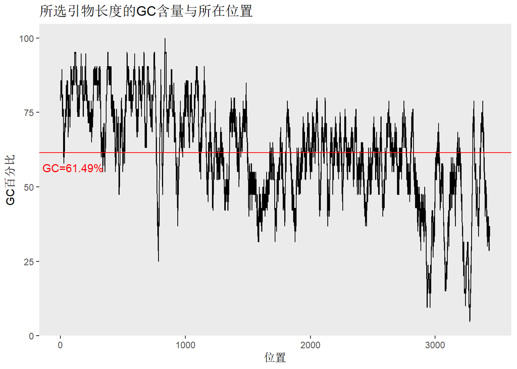

```r
library(ggplot2)

CG_overview <-
  ggplot(data = F_primer_all, aes(x=start, y=GC))+
  geom_line(pch=2) +
  ggtitle("所选引物长度的GC含量与所在位置")+
  labs(x = "位置", y = "GC百分比")+
  geom_hline(aes(yintercept = target_GC), colour = "red") +
  annotate('text', x = 100, y = target_GC-5, label = paste0("GC=",target_GC,"%"), colour = "red") +
  theme(panel.grid = element_blank())

primer_sets_overview <-
  ggplot(data = primer_sets, aes(x=R_start, y =1)) +
  geom_segment(aes(x=0, y=0, xend = target_size, yend = 0))+
  geom_segment(aes(x=target_size-R_start, y = 0.5, xend = target_size-R_end, yend = 0.5),data = primer_sets, color = "red") +
  geom_segment(aes(x=F_start, y = 1, xend = F_end, yend = 1),data = primer_sets, color = "blue")+
  ggtitle("正反向可用引物在靶标上的位置")+
  labs(x = "基因位置",y = "")+
  coord_fixed(ratio = 500)+
  theme(axis.ticks = element_blank(),axis.text.y = element_blank())+
  annotate("text",x=0, y = 1, label = "Forward", color = "blue")+
  annotate("text",x=0, y =0.5,label = "Reverse", color = "red")

CG_overview
```

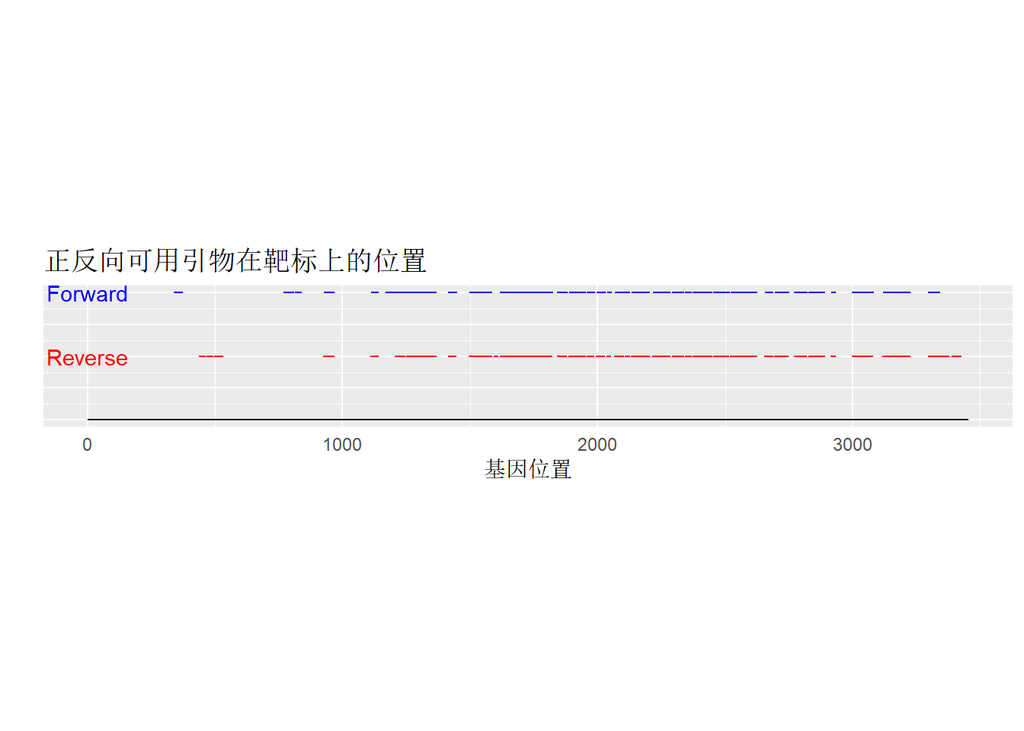

```r
primer_sets_overview
```

## 输出结果到结果目录

```r
write.csv(primer_sets,file = "~/R_project/primer_sets.csv",row.names = F)
```